# PracaDom5_MBogdańska

Magdalena Bogdańska

Modele liniowe i mieszane

## Task

The data sleepstudy (lme4) allow to measure the effect of sleep deprivation on reaction time.

On day 0 people (subjects of the study) had their normal amount of sleep. From that night on, they were restricted to 3 hours of sleep per night. The observations represent the average reaction time on a series of tests done each day by each person (subject).

With the use of the sleepstudy:

- Plot the relation between Reaction and Days for each subject independently.
- Build a model with random coefficients for linear trend between Reaction and Days.
- Extract individual slopes for the relation from the model with random effects. Present summary statistics of these slopes (1Q, median, 3Q).

## Part 1

Data to be considered is of a following form:

```r
head(sleepstudy)
```

```
##   Reaction Days Subject
## 1 249.5600    0     308
## 2 258.7047    1     308
## 3 250.8006    2     308
## 4 321.4398    3     308
## 5 356.8519    4     308
## 6 414.6901    5     308
```

In order to plot results for patients separatly, first I prepare the panel for lattice package which will contain both linear and quadratic trend lines marked with blue and red lines, respectively. Subsequently with function xyplot I plot reaction times as a function of time of the test for all patients (as during classes).

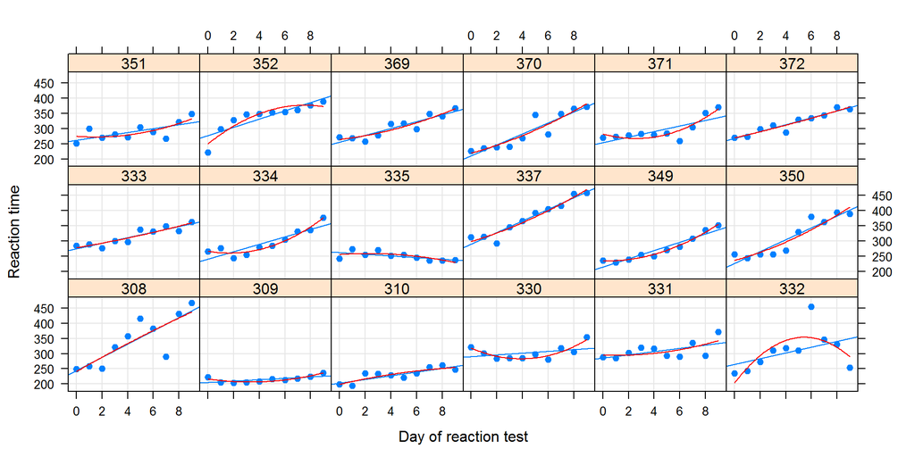

```r
panel.with.square <- function(...){
  nx = list(...)$x
  ny = list(...)$y
  cc = lm(ny~nx+I(nx^2))$coef
  panel.xyplot(...)
  panel.curve(x^2*cc[3]+x*cc[2]+cc[1], from=min(nx), to=max(nx), col="red")
}
xyplot(Reaction ~ Days | Subject, sleepstudy, type = c("g","p","r"),
  xlab = "Day of reaction test", ylab = "Reaction time", pch=19,
  panel = panel.with.square)
```

One can see a general increasing trend for reaction time, namely the more time one lacks enough sleep, the longer is the reaction time in proper physical tests. There is only one person which doesn’t follow this general rule (with id=335). Moreover slopes of linear trends for each subject are different.

## Part 2

First let me try a model with only one random effect, namely the effect of the indivudual (subject).

```r
(model0<-lmer(Reaction~Days + (1|Subject), data=sleepstudy))
```

```
## Linear mixed model fit by REML ['lmerMod']
## Formula: Reaction ~ Days + (1 | Subject)
##    Data: sleepstudy
## REML criterion at convergence: 1786.465
## Random effects:
##  Groups   Name        Std.Dev.
##  Subject  (Intercept) 37.12
##  Residual             30.99
## Number of obs: 180, groups:  Subject, 18
## Fixed Effects:
## (Intercept)         Days
##      251.41        10.47
```

However in the plot we can see some trend, so I reject this initial model. I will try with a linear relation.

```r
(model1 <- lmer(Reaction ~ Days + (Days|Subject), data=sleepstudy))
```

```
## Linear mixed model fit by REML ['lmerMod']
## Formula: Reaction ~ Days + (Days | Subject)
##    Data: sleepstudy
## REML criterion at convergence: 1743.628
## Random effects:
##  Groups   Name        Std.Dev. Corr
##  Subject  (Intercept) 24.740
##           Days         5.922   0.07
##  Residual             25.592
## Number of obs: 180, groups:  Subject, 18
## Fixed Effects:
## (Intercept)         Days
##      251.41        10.47
```

```r
anova(model0,model1)
```

```
## Data: sleepstudy
## Models:
## model0: Reaction ~ Days + (1 | Subject)
## model1: Reaction ~ Days + (Days | Subject)
##        Df    AIC    BIC  logLik deviance  Chisq Chi Df Pr(>Chisq)
## model0  4 1802.1 1814.8 -897.04   1794.1
## model1  6 1763.9 1783.1 -875.97   1751.9 42.139      2  7.072e-10 ***
## ---
## Signif. codes:  0 '***' 0.001 '**' 0.01 '*' 0.05 '.' 0.1 ' ' 1
```

Result of Anova confirm previous natural hypothesis (that effect of days is important).

Neglecting existence of dependence, one could consider also the following model:

```r
(model2 <- lmer(Reaction ~ Days + (Days-1|Subject) + (1|Subject), data=sleepstudy))
```

```
## Linear mixed model fit by REML ['lmerMod']
## Formula: Reaction ~ Days + (Days - 1 | Subject) + (1 | Subject)
##    Data: sleepstudy
## REML criterion at convergence: 1743.669
## Random effects:
##  Groups    Name        Std.Dev.
##  Subject   Days         5.988
##  Subject.1 (Intercept) 25.051
##  Residual              25.565
## Number of obs: 180, groups:  Subject, 18
## Fixed Effects:
## (Intercept)         Days
##      251.41        10.47
```

```r
anova(model1,model2)
```

```
## Data: sleepstudy
## Models:
## model2: Reaction ~ Days + (Days - 1 | Subject) + (1 | Subject)
## model1: Reaction ~ Days + (Days | Subject)
##        Df    AIC    BIC  logLik deviance  Chisq Chi Df Pr(>Chisq)
## model2  5 1762.0 1778.0 -876.00   1752.0
## model1  6 1763.9 1783.1 -875.97   1751.9 0.0639      1     0.8004
```

As p-value is high, it is not necessary to take into account the correlation. Thus I will consider subsequently model2.

## Part 3

I extract individual slopes with the command below and present values of median, first and third quantile.

```r
(slopes_model2<- ranef(model2)$Subject[,1] + fixef(model2)[2])
```

```
##  [1] 19.7907752  1.8681169  5.0794955  5.4986402  7.2733512 10.1587924
##  [7] 10.1800786 11.5832760 -0.4386803 19.0949020 11.7479737 17.2236864
## [13]  7.3921530 13.9794956 11.3403366 15.4510724  9.4619930 11.7256888
```

```r
summary(slopes_model2)[c(2,3,5)]
```

```
## 1st Qu.  Median 3rd Qu.
##   7.303  10.760  13.420
```

We can see that only one slope is negative (as seen previously in the plot). For other indivuduals there is an increasing linear trend.